# OutFLANK: Finding FST outliers with an inferred neutral distribution

Michael C. Whitlock and Katie E. Lotterhos

whitlock@zoology.ubc.ca; k.lotterhos@neu.edu

OutFLANK is an R package that implements the method developed by Whitlock and Lotterhos to use likelihood on a trimmed distribution of FST values to infer the distribution of FST for neutral markers. This distribution is then used to assign q-values to each locus to detect outliers that may be due to spatially heterogeneous selection.

Whitlock, M. C., and K. E. Lotterhos. Reliable detection of loci responsible for local adaptation: Inference of a neutral model through trimming the distribution of FST. The American Naturalist.

Please see this paper for a discussion of the limitations and strengths of this approach.

## To load OutFLANK

OutFLANK is distributed through github. To install the OutFLANK package, first install the devtools package on your session of R, followed by the installation of OutFLANK from github.

```r
### Install required package devtools if not installed
install.packages("devtools")
library(devtools)

### Install required package qvalue
  source("http://bioconductor.org/biocLite.R")
  biocLite("qvalue")

### Install OutFLANK

install_github("whitlock/OutFLANK")
```

Next, load the package into your R session.

```r
library(OutFLANK)
```

## Steps to running OutFLANK

1. Prepare a dataframe for the OutFLANK function
   - From a formatted SNP dataset using `MakeDiploidFSTMat()`
   - From your own data using functions provided with the package (see Section “For Advanced Users”)
2. Check for SNPs of low sample size or that have Fst values differentially affected by sample size correction
3. Run OutFLANK
4. Plot results

## Preparing input files for OutFLANK

The input for the `OutFLANK()` function is a data frame, with a row for each locus. OutFLANK requires that the input data include a large number of loci not strongly affected by spatially heterogeneous selection, although these need not be previously identified. It will work best with at least thousands of loci in the data set.

OutFLANK finds outliers for FST, but it needs to use estimates of FST that have not been corrected for sample size adjustments. This is because these sample size adjustments can sometimes cause the estimate of the FST of a locus to be negative, which is not a possible value of the chi-squared distribution used by OutFLANK. These uncorrected values are labeled with “NoCorr”, e.g. FSTNoCorr is the FST of a locus without this correction. (In order to properly average FST over loci, OutFLANK also needs the numerator and denominator of the FST calculation for FSTNoCorr; these are called T1NoCorr and T2NoCorr respectively, for more information see the section “For Advanced Users”).

Since only uncorrected values of Fst are used in the algorithm, loci with unusually low sample sizes relative to the rest of the loci could be called as outliers. The user should take care to remove them before analysis. For a discussion of this issue see the publication.

There are several required columns in the input data frame, which you can read about in the section “Running OutFLANK”. Some of the columns in the input are somewhat unusual, and functions to create the values in these columns are also included in the package. We anticipate that most people will be starting with SNP datasets and will need these variables to be calculated, as described below. You can, however, calculate these quantities yourself with functions provided in the package (see section “For advanced users”).

For diploid data, the appropriate input data frame can be calculated using the function:

`MakeDiploidFSTMat(SNPmat,locusNames,popNames)`.

The output of this function is a data frame that can be given to the function `OutFLANK()` as the input parameter `FSTDataFrame` (see below). This function requires three data objects as input:

- `SNPmat` is an array with a row for each individual in the data set and a column for each locus. This function assumes biallelic (i.e. SNP) data, and the value in each column is either 0, 1 or 2, showing the number of the focal alleles that the individual carries at that locus. (i.e., 2 means that the individual is a homozygote for the focal allele, 0, means that the individual has no copies of that focal allele, and 1 indicates a heterozygote.) For any locus that is unknown for an individual, SNPmat should have a 9 for that locus on that row. The function will take a few minutes to check that your data only contain 0, 1, 2, and 9, and it will produce an error if your data contains any other values.
- `locusNames` is a character vector that gives a list of identifying names for each locus. (The length of the `locusNames` vector should be the same as the number of columns in `SNPmat`.)
- `popNames` is a character vector that has an entry for each individual, in the same order as the rows in `SNPmat`, which gives the population that that individual came from. OutFLANK assumes that the individuals are grouped into relatively discrete populations, so there must be multiple individuals per population for the function to work properly.

### Load example data

The dataset we will use was simulated with the program [Nemo v2.3](http://nemo2.sourceforge.net/). In this simulation, a quantitative trait was adapting to a single environmental variable across 19 populations located on a two dimensional landscape. The species was originally confined to two populations during glaciation, and over time expanded across the range. Dispersal depended on geographic distance among the populations.

There were 30 QTL that had moderate effects on the phenotype. The phenotype was under stabilizing selection in each population, although the optimum phenotype differed among populations. QTL and 1002 neutral loci were randomly distributed across 6 chromosomes. As you will see, this dataset presents a challenging case for OutFLANK (as it would other FST outlier tests).

Set your working directory to the example set (this code will work if the example data is on your desktop):

```r
setwd("~/Desktop/OutFLANKexample")
```

Load the data:

```r
### The SNP data
  SNPdata <- read.table("species1_a_diallelic.mig.1trait_5000_1.data", header=FALSE)
  ### Show the first 5 SNPs in the first 6 individuals:
  head(SNPdata[,1:5])
```

```
##   V1 V2 V3 V4 V5
## 1  0  1  1  0  1
## 2  0  1  1  1  1
## 3  0  2  0  1  1
## 4  0  1  1  0  2
## 5  1  1  1  0  0
## 6  1  0  0  2  1
```

```r
### The individual data
  ind <- read.table("species1_a_diallelic.mig.1trait_5000_1.pop", header=TRUE)
  ind <- as.character(ind$x)
  head(ind)
```

```
## [1] "pop_1" "pop_1" "pop_1" "pop_1" "pop_1" "pop_1"
```

```r
### The loci info
  loci <- read.table("species1_a_diallelic.mig.1trait.lociinfo", header=TRUE)
  head(loci)
```

```
##   chrom cM type
## 1     1  0 ntrl
## 2     1  0 ntrl
## 3     1  1 ntrl
## 4     1  3 ntrl
## 5     1  4 ntrl
## 6     1  5 ntrl
```

```r
  ### The loci are ordered so that the QTL are at the end of the dataset:
  tail(loci)
```

```
##      chrom cM   type
## 1027     5 88 quanti
## 1028     6 10 quanti
## 1029     6 44 quanti
## 1030     6 50 quanti
## 1031     6 53 quanti
## 1032     6 99 quanti
```

```r
  ### Note above how the first two columns indicate the genetic map.
  ### Let's make a character vector of locus names:
  locinames <- paste(loci[,1], loci[,2], loci[,3], sep="_")
  head(locinames)
```

```
## [1] "1_0_ntrl" "1_0_ntrl" "1_1_ntrl" "1_3_ntrl" "1_4_ntrl" "1_5_ntrl"
```

```r
  ### Let's look at the data we are dealing with:
  table(loci$type)
```

```
##
##   ntrl quanti
##   1002     30
```

## Calculate variables required for `OutFLANK()` function

Here are the columns required for the input data frame. They should have these names, but order does not matter:

- `$LocusName`: a character string that uniquely names each locus.
- `$FST`: FST calculated for this locus by Weir and Cockerham (1984). (Kept here to report the unbiased FST of the results)
- `$T1`: The numerator of the estimator for FST (necessary, with $T2, to calculate mean FST)
- `$T2`: The denominator of the estimator of FST
- `$FSTNoCorr`: FST calculated for this locus without sample size correction. (See below for the functions used to calculate this and the next two columns)
- `$T1NoCorr`: The numerator of the estimator for FST without sample size correction (necessary, with $T2$, to find mean FST)
- `$T2NoCorr`: The denominator of the estimator of FST without sample size correction
- `$He`: The heterozygosity of the locus (used to screen out low heterozygosity loci that have a different distribution)

We are going to use the `MakeDiploidFSTMat()` function to calculate these variables from the SNP data:

```r
 FstDataFrame <- MakeDiploidFSTMat(SNPdata,locinames,ind)
```

```
## Calculating FSTs, may take a few minutes...
```

```r
  head(FstDataFrame)
```

```
##   LocusName        He         FST           T1        T2  FSTNoCorr
## 1  1_0_ntrl 0.4218496 0.038142372 0.0080698589 0.2115720 0.05635356
## 2  1_0_ntrl 0.4902650 0.007235449 0.0017761964 0.2454853 0.02701353
## 3  1_1_ntrl 0.4490433 0.027018243 0.0060814692 0.2250875 0.04653193
## 4  1_3_ntrl 0.4568205 0.010181042 0.0023291558 0.2287738 0.02976019
## 5  1_4_ntrl 0.3358706 0.012466439 0.0020972301 0.1682301 0.03275146
## 6  1_5_ntrl 0.2975207 0.001955359 0.0002912155 0.1489320 0.02185450
##      T1NoCorr  T2NoCorr meanAlleleFreq
## 1 0.011923410 0.2115822      0.6976744
## 2 0.006631771 0.2454981      0.4302326
## 3 0.010474297 0.2250991      0.3403805
## 4 0.006808705 0.2287857      0.6469345
## 5 0.005510076 0.1682391      0.2135307
## 6 0.003255005 0.1489398      0.1818182
```

Since this is a simulated dataset and we know the truth about the SNPs, let’s append that information to the `FstDataFrame` before we run `OutFLANK()`. The input can also include other columns, which will be ignored by OutFLANK as long as their names do not include `$GoodH`, `$q`, `$OutlierFlag`, or `$indexOrder`, in addition to the columns listed above.

```r
  FstDataFrame2 <- data.frame(FstDataFrame, loci)
  head(FstDataFrame2)
```

```
##   LocusName        He         FST           T1        T2  FSTNoCorr
## 1  1_0_ntrl 0.4218496 0.038142372 0.0080698589 0.2115720 0.05635356
## 2  1_0_ntrl 0.4902650 0.007235449 0.0017761964 0.2454853 0.02701353
## 3  1_1_ntrl 0.4490433 0.027018243 0.0060814692 0.2250875 0.04653193
## 4  1_3_ntrl 0.4568205 0.010181042 0.0023291558 0.2287738 0.02976019
## 5  1_4_ntrl 0.3358706 0.012466439 0.0020972301 0.1682301 0.03275146
## 6  1_5_ntrl 0.2975207 0.001955359 0.0002912155 0.1489320 0.02185450
##      T1NoCorr  T2NoCorr meanAlleleFreq chrom cM type
## 1 0.011923410 0.2115822      0.6976744     1  0 ntrl
## 2 0.006631771 0.2454981      0.4302326     1  0 ntrl
## 3 0.010474297 0.2250991      0.3403805     1  1 ntrl
## 4 0.006808705 0.2287857      0.6469345     1  3 ntrl
## 5 0.005510076 0.1682391      0.2135307     1  4 ntrl
## 6 0.003255005 0.1489398      0.1818182     1  5 ntrl
```

Note that it is better practice to append all the information about each locus to the dataframe before you run `OutFLANK()`, because the order of loci after you run the function may be sorted differently from the input list.

### Check for loci with low sample sizes or unusual values of uncorrected FST

The procedure implemented in `OutFLANK()` will use a measure of FST uncorrected for sample size, because correction for sample size results in negative values of FST that cannot be fit by a chi-square distribution. Assuming all loci have equal sample sizes, the ranks of the uncorrected FSTs (`$FSTNoCorr`) are equivalent to the ranks of the FSTs that have been corrected for sample size (`FST`).

We can check the amount of missing data by summing the number of “9” values in each column:

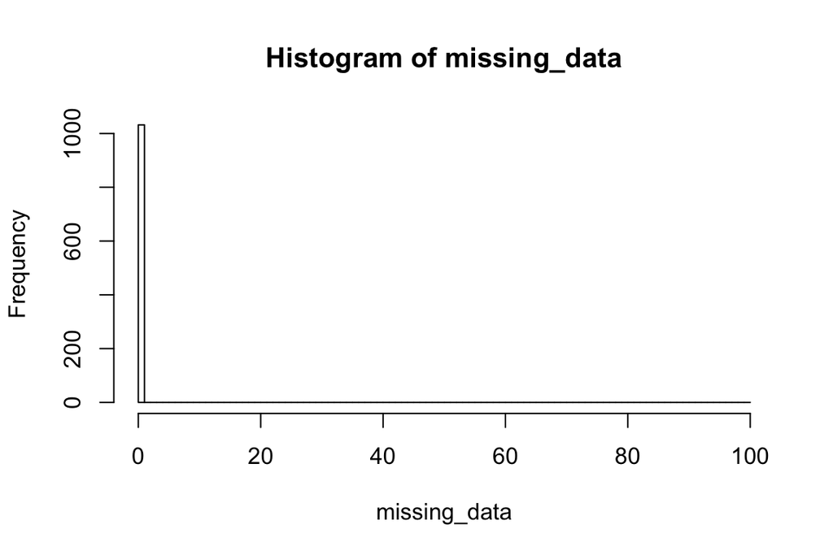

```r
  ### a vector indicating the amount of missing data for each locus:
  missing_data <- apply(SNPdata,2, function(i){sum(i==9)})
  hist(missing_data, breaks=seq(0,100,1))
```

In this dataset, no loci are missing any data.

Let’s plot the corrected vs. uncorrected FSTs:

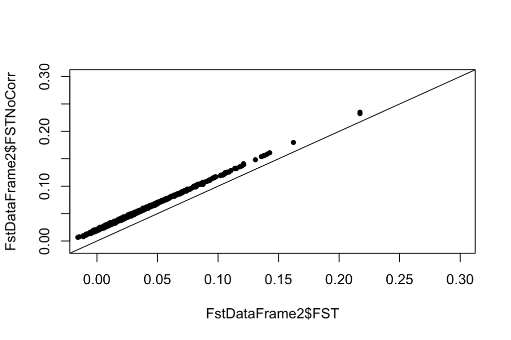

```r
plot(FstDataFrame2$FST, FstDataFrame2$FSTNoCorr,
     xlim=c(-0.01,0.3), ylim=c(-0.01,0.3),
     pch=20)
abline(0,1)
```

Note how the distribution of `$FSTNoCorr` is shifted slightly higher than the corrected `$FST` distribution, but the ranks are the same.

### What if a locus has low sample size?

To demonstrate this problem, let’s severly decrease the sample size of the first locus (such that 200 randomly chosen individuals will be missing data for that locus).

```r
SNPdata_missing <- SNPdata
missing <- sample(1:nrow(SNPdata), 200, replace=FALSE)
SNPdata_missing[missing,1] <- 9
FstDataFrame_missing <- MakeDiploidFSTMat(SNPdata_missing,locinames,ind)
```

```
## Calculating FSTs, may take a few minutes...
```

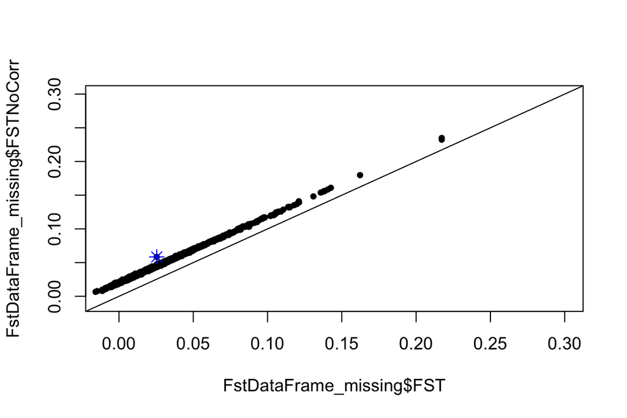

```r
  plot(FstDataFrame_missing$FST, FstDataFrame_missing$FSTNoCorr, xlim=c(-0.01,0.3), ylim=c(-0.01,0.3), pch=20)
  ## Highlight the SNP that is missing a lot of data
  points(FstDataFrame_missing$FST[1], FstDataFrame_missing$FSTNoCorr[1], col="blue", pch=8, cex=1.3)
  abline(0,1)
```

Note how the SNP missing a lot of data has an elevated value of uncorrected FST relative to corrected FST. SNPs like this should be removed before running OutFLANK.

## Running OutFLANK

Once the appropriate input dataframe is available (see above), the procedure can be run with one command:

```
OutFLANK(FstDataFrame, LeftTrimFraction=0.05, RightTrimFraction=0.05, Hmin=0.1, NumberOfSamples, qthreshold=0.05)
```

- `FstDataFrame` is the input prepared above. (If your dataframe for OutFLANK is called “`myFs`”, then the argument would read `FstDataFrame = myFs`.)
- `LeftTrimFraction` and `RightTrimFraction` are arguments, each set to 5% by default, to tell OutFLANK how many of the lowest and highest FST values to remove before estimating the shape of the FST distribution through likelihood. (This removes the loci most affected by selection, and the likelihood procedure in OutFLANK accounts for the fact that data below and above these thresholds have been removed.) In some cases, when there are potentially a large number of loci affected by spatially heterogeneous selection, it can be worth trying a higher `RightTrimFraction`.
- `Hmin` is the threshold for expected heterozygosity. Loci with low He have distributions of FST very different from loci with higher He, and it is important to screen these out before proceeding. By default, OutFLANK removes from consideration all loci with expected heterozygosity less than 10%.
- `NumberOfSamples` is the number of populations sampled. This is the only other argument without a default, aside from the data frame.
- `qthreshold` sets the threshold for whether a locus is deemed an “outlier”, i.e. if the q-value for that locus is below this threshold. This is set to 5% by default (aiming at a 5% or lower false discovery rate.) These q-values are calculated based on the right-tail P-values for each locus.

Let’s run OutFLANK with default options:

```r
OF <- OutFLANK(FstDataFrame2, NumberOfSamples=19)
```

### Values output by OutFLANK

OutFLANK returns a data frame with the following values:

- `$FSTbar`: Mean FST of loci not flagged as outliers, using the sample-size correction (recommend reporting in publication)
- `$FSTNoCorrbar`: Mean FST of loci not flagged as outliers, without using the sample-size correction
- `$dfInferred`: Inferred df for the chi-square distribution from the OutFLANK procedure (recommend reporting in publication).
- `$numberLowFstOutliers`: Number of loci flagged as having a significantly low FST (not reliable)
- `$numberHighFstOutliers`: Number of loci flagged as having a significantly high FST.
- `$results`: a data frame with a row for each locus. This data frame includes all the original columns in the input data set, and six new ones:
- `$results$indexOrder`: the original row number of the locus in the input data set
- `$results$GoodH`: Boolean variable which is TRUE if the expected heterozygosity is greater than the `Hemin` set by the input to OutFLANK
- `$results$OutlierFlag`: TRUE if the method identifies the locus as an outlier, FALSE otherwise, based on the q-threshold
- `$results$q`: the q-value for the test of neutrality for the locus, based on the right-tailed P-value.
- `$results$pvalues`: the two-tailed P-value for the test of neutrality for the locus. Not reliable, because OutFLANK does not predict the left-tailed P-values well.
- `$results$pvaluesRightTail`: the one-sided (right tail) P-value for the locus

Let’s look at these values for our data

```r
  str(OF)
```

```
## List of 6
##  $ FSTbar               : num 0.0297
##  $ FSTNoCorrbar         : num 0.0493
##  $ dfInferred           : num 6.85
##  $ numberLowFstOutliers : int 0
##  $ numberHighFstOutliers: int 2
##  $ results              :'data.frame':   1032 obs. of  18 variables:
##   ..$ LocusName       : Factor w/ 519 levels "1_0_ntrl","1_1_ntrl",..: 1 1 2 26 36 46 46 46 55 55 ...
##   ..$ He              : num [1:1032] 0.422 0.49 0.449 0.457 0.336 ...
##   ..$ FST             : num [1:1032] 0.03814 0.00724 0.02702 0.01018 0.01247 ...
##   ..$ T1              : num [1:1032] 0.00807 0.00178 0.00608 0.00233 0.0021 ...
##   ..$ T2              : num [1:1032] 0.212 0.245 0.225 0.229 0.168 ...
##   ..$ FSTNoCorr       : num [1:1032] 0.0564 0.027 0.0465 0.0298 0.0328 ...
##   ..$ T1NoCorr        : num [1:1032] 0.01192 0.00663 0.01047 0.00681 0.00551 ...
##   ..$ T2NoCorr        : num [1:1032] 0.212 0.245 0.225 0.229 0.168 ...
##   ..$ meanAlleleFreq  : num [1:1032] 0.698 0.43 0.34 0.647 0.214 ...
##   ..$ chrom           : int [1:1032] 1 1 1 1 1 1 1 1 1 1 ...
##   ..$ cM              : int [1:1032] 0 0 1 3 4 5 5 5 6 6 ...
##   ..$ type            : Factor w/ 2 levels "ntrl","quanti": 1 1 1 1 1 1 1 1 1 1 ...
##   ..$ indexOrder      : int [1:1032] 1 2 3 4 5 6 7 8 9 10 ...
##   ..$ GoodH           : Factor w/ 2 levels "goodH","lowH": 1 1 1 1 1 1 1 1 1 1 ...
##   ..$ qvalues         : num [1:1032] 0.716 0.716 0.716 0.716 0.716 ...
##   ..$ pvalues         : num [1:1032] 0.665 0.411 0.939 0.501 0.602 ...
##   ..$ pvaluesRightTail: num [1:1032] 0.333 0.795 0.47 0.75 0.699 ...
##   ..$ OutlierFlag     : logi [1:1032] FALSE FALSE FALSE FALSE FALSE FALSE ...
```

## Plotting Results: The inferred neutral FST distribution

We recommend that you plot the distribution of `FSTNoCorr` for your loci against the inferred distribution and include this as a supplemental file in your publication. The included function `OutFLANKResultsPlotter` uses the output of OutFLANK to plot the distribution of `FSTNoCorr`:

```
OutFLANKResultsPlotter(OFoutput, withOutliers = TRUE, NoCorr = TRUE,
  Hmin = 0.1, binwidth = 0.005, Zoom = FALSE, RightZoomFraction = 0.05,
  titletext = NULL)
```

- `OFoutput` is the output of the function `OutFLANK()`. Run `OutFLANK()` first, storing the results to a variable.
- `withOutliers` determines whether to include loci flagged by OutFLANK as outliers in the histogram
- `NoCorr = TRUE` tells the function to plot `FSTNoCorr` instead of FST. This is recommended, because the distribution curve plotted will be predicted for `FSTNoCorr`, not `FST` itself.
- `Hmin` tells the function the minimum expected heterozygosity that a locus should have before it is included in the plots.
- `binwidth` describes the width of the histogram bins.
- `Zoom` provides the option of “zooming in” on the right hand tail of the distribution. When `Zoom = TRUE`, only loci in the highest quantiles of FST will be plotted (with the proportion included determined by RightZoomFraction.)
- `titletext` provides an opportunity to provide a title for the graph. Put the phrase you want as the title in “quotes”.

Let’s plot our results:

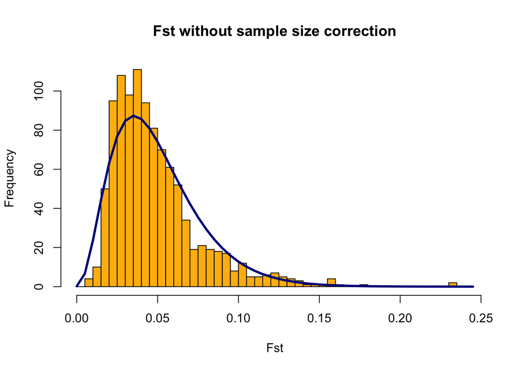

```r
OutFLANKResultsPlotter(OF, withOutliers = TRUE, NoCorr = TRUE,
                       Hmin = 0.1, binwidth = 0.005, Zoom = FALSE,
                       RightZoomFraction = 0.05, titletext = NULL)
```

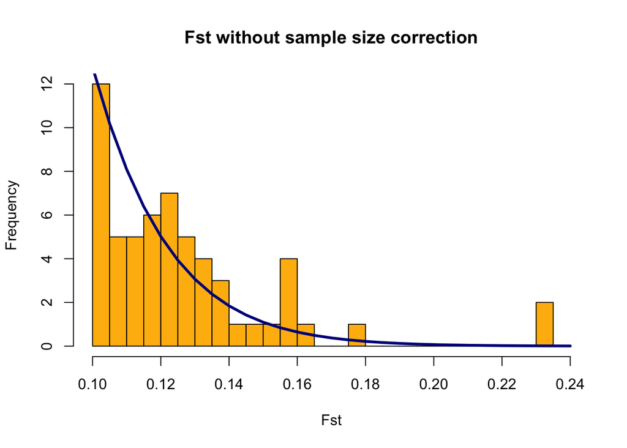

```r
OutFLANKResultsPlotter(OF, withOutliers = TRUE, NoCorr = TRUE,
                       Hmin = 0.1, binwidth = 0.005, Zoom = TRUE,
                       RightZoomFraction = 0.05, titletext = NULL)
```

We can also plot the popular He vs. FST plot and highlight the outliers:

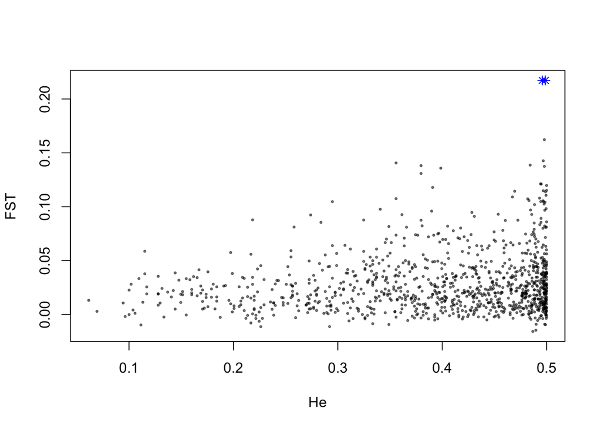

```r
plot(OF$results$He, OF$results$FST, pch=20, col= rgb(0,0,0,0.5), cex=0.5,
     xlab="He", ylab="FST")
points(OF$results$He[OF$results$OutlierFlag], OF$results$FST[OF$results$OutlierFlag], pch=8, col= rgb(0,0,1,1))
```

OutFLANK inferred two outliers in our dataset.

## What was the truth?

Because we used simulations, we know which loci were neutral and which were qtl. Let’s look at how well OutFLANK performed on this simulation by making the above plot again, but by coloring the qtl orange and outlining the outliers in blue:

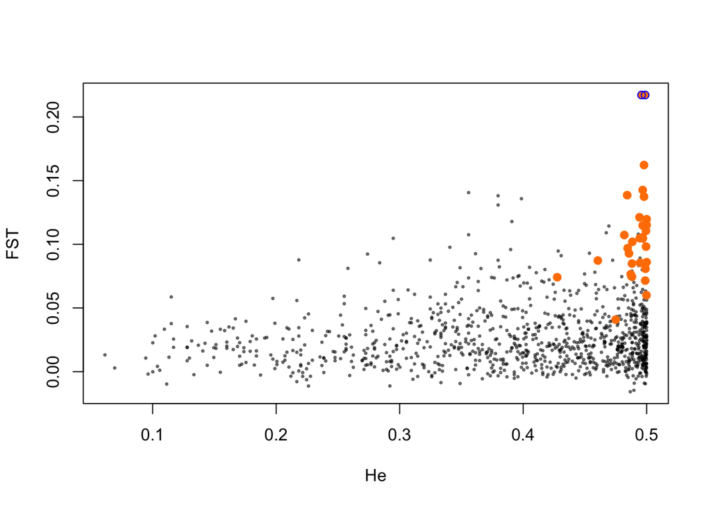

```r
plot(OF$results$He, OF$results$FST, pch=20, col= rgb(0,0,0,0.5), cex=0.5,
     xlab="He", ylab="FST")

### Color qtl in orange
points(OF$results$He[OF$results$type=="quanti"], OF$results$FST[OF$results$type=="quanti"], pch=19, col= rgb(1,0.5,0,1))

### Outline outliers in blue
points(OF$results$He[OF$results$OutlierFlag], OF$results$FST[OF$results$OutlierFlag], pch=1, col= rgb(0,0,1,1))
```

There were several QTL not called as outliers by OutFLANK. This illustrates an important point about the OutFLANK algorithm: it only flags loci that are truly outliers compared to the inferred neutral FST distribution. This dataset illustrates a difficult case for FST outlier tests, because many of the QTL have elevated FST values, but they are not outliers relative to the neutral loci.

To see how well OutFLANK performed, we see how well the q-value cutoff (the desired false discovery rate, FDR) matches the actual FDR.

> FDR = (number of false positives)/(total number of positive tests)

Ideally we want to minimize this rate in genome scans.

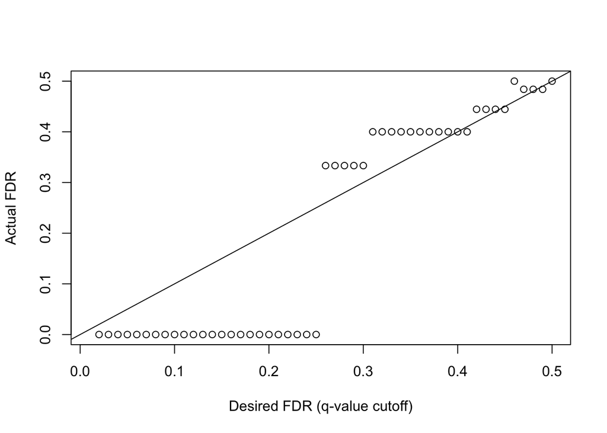

```r
desiredFDR <- seq(0.01,0.5,by=0.01)
trueFDR<-rep(NA, length(desiredFDR))
### Loop through different q-value cutoffs (desired false discovery rates)
    for (i in 1:length(desiredFDR)){
      WhichPos <- OF$result$qvalues<=desiredFDR[i]

      # total number of outliers called at that q-value threshold
      NumPos <- sum(WhichPos)

      # number that are false positives
      FalsePos <- sum(WhichPos[OF$result$type=="ntrl"])

      trueFDR[i]<-FalsePos/NumPos
    }

# Plot the desired vs. acutual FDRs
plot(desiredFDR, trueFDR, xlab="Desired FDR (q-value cutoff)", ylab="Actual FDR")
abline(0,1)
```

Let’s look at the distribution of q-values:

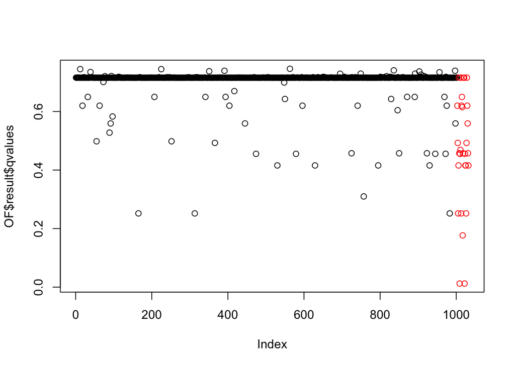

```r
plot(OF$result$qvalues, col=(OF$result$type))
```

If you chose a qvalue cutoff of 0.3 for this dataset you would have:

```r
table(OF$result$type[OF$result$qvalues<0.3])
```

```
##
##   ntrl quanti
##      3      6
```

```r
### 9 outliers and 3 of them would be neutral
```